# Stat 11 Week 13

Practice with Statistical Inference

Prof. Suzy Thornton

# 1. Data Introduction

The [in-class worksheet for Week 13](https://dr-suz.github.io/Stat11/wk13-wksheet.html) proposes several different research questions, each answerable with a hypothesis test. First you will familiarize yourself with each research question. Then you will work with your group mates to solve the research questions.

Below is a table showing all possible conclusions we can make from a hypothesis test and all possible mistakes we could make. We will cover the different types of mistakes (or errors) next class.

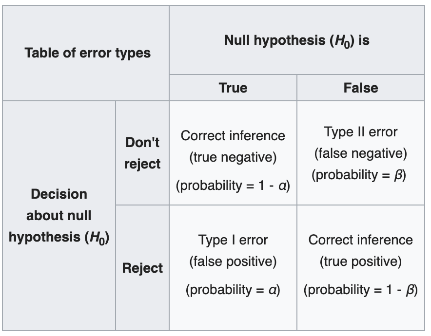

Image source: [wiki](https://en.wikipedia.org/wiki/Type_I_and_type_II_errors)

# 2. Analysis Goals

- Apply your understanding of the inference methods we’ve covered thus far including
  - One sample inference for a proportion or mean
  - Two sample inference for proportions or means of independent groups
  - Two paired samples inference for a mean
  - Inference for categorical data with Chi-squared procedures
- Recognize the important role of statistical analysis that does not involve any mathematical or computational calculations.

# 3. Summary of Results

- For various research questions, you can design a careful statistical inference procedure that can provide a relevant answer. Confidence intervals are useful when we want to know an estimate for the actual size of the unknown parameter(s) whereas hypothesis tests are useful when we want to make a decision based on evidence in our data.
- To determine which statistical inference procedure to use, we must carefully understand what data is being collected. Fundamental questions we learned in Unit 1 help us determine how to proceed. Questions such as: what are the variables? what are the variable types? what is the population of interest? and what are the observational unit in our sample? all help us determine which procedure to use.